# Séance 4 : Matrices et listes

Introduction au langage R

Mouhamadou Lamine NDAO

Cnam · USSI6B-1 · Introduction au langage R

17 novembre 2026

## Au programme

**Matrices et arrays**

1. Qu’est-ce qu’une matrice ?
2. Créer et nommer
3. Indexer en deux dimensions
4. Calcul élément par élément et calcul matriciel
5. Résumés par ligne et par colonne
6. Arrays : plus de deux dimensions

**Listes**

7. Pourquoi des listes ?
8. Créer et accéder : `[ ]`, `[[ ]]`, `$`
9. Modifier et imbriquer
10. Les fonctions renvoient des listes

**Bilan**

11. Vecteur, facteur, matrice, liste, data frame : lequel choisir ?
12. Conversions et pièges

# Les matrices

## Une matrice, c’est quoi ?

Une matrice est un vecteur auquel on a donné deux dimensions : des lignes et des colonnes.

```r
m <- matrix(1:6, nrow = 2, ncol = 3)
m
```

```
#>      [,1] [,2] [,3]
#> [1,]    1    3    5
#> [2,]    2    4    6
```

```r
dim(m)                 # un vecteur + un attribut « dim »
```

```
#> [1] 2 3
```

Comme un vecteur, une matrice n’a **qu’un seul type** :

```r
matrix(c(1, "a", TRUE, 2), 2)
```

```
#>      [,1] [,2]
#> [1,] "1"  "TRUE"
#> [2,] "a"  "2"
```

Pour mélanger des types, on utilise un data frame. Les matrices servent aux données homogènes : mesures, images, algèbre linéaire.

## Créer une matrice

```r
matrix(1:6, nrow = 2)                  # remplissage par colonne (défaut)
```

```
#>      [,1] [,2] [,3]
#> [1,]    1    3    5
#> [2,]    2    4    6
```

```r
matrix(1:6, nrow = 2, byrow = TRUE)    # remplissage par ligne
```

```
#>      [,1] [,2] [,3]
#> [1,]    1    2    3
#> [2,]    4    5    6
```

```r
matrix(0, nrow = 2, ncol = 4)          # recyclage d'une seule valeur
```

```
#>      [,1] [,2] [,3] [,4]
#> [1,]    0    0    0    0
#> [2,]    0    0    0    0
```

```r
diag(3)                    # matrice identité
```

```
#>      [,1] [,2] [,3]
#> [1,]    1    0    0
#> [2,]    0    1    0
#> [3,]    0    0    1
```

```r
rbind(c(1, 2), c(3, 4))    # empiler des lignes
```

```
#>      [,1] [,2]
#> [1,]    1    2
#> [2,]    3    4
```

```r
cbind(a = 1:2, b = 3:4)    # juxtaposer des colonnes
```

```
#>      a b
#> [1,] 1 3
#> [2,] 2 4
```

## Nommer lignes et colonnes

```r
notes <- matrix(c(12, 15, 9, 14, 17, 11, 10, 13, 16), nrow = 3, byrow = TRUE)
rownames(notes) <- c("Awa", "Bruno", "Chen")
colnames(notes) <- paste0("DS", 1:3)
notes
```

```
#>       DS1 DS2 DS3
#> Awa    12  15   9
#> Bruno  14  17  11
#> Chen   10  13  16
```

```r
dimnames(notes)                        # une liste : noms de lignes, noms de colonnes
```

```
#> [[1]]
#> [1] "Awa"   "Bruno" "Chen"
#>
#> [[2]]
#> [1] "DS1" "DS2" "DS3"
```

```r
matrix(1:4, 2, dimnames = list(c("h", "f"), c("oui", "non")))
```

```
#>   oui non
#> h   1   3
#> f   2   4
```

## Indexer : `[ligne, colonne]`

```r
notes[2, 3]              # un élément
```

```
#> [1] 11
```

```r
notes["Bruno", "DS3"]    # par noms
```

```
#> [1] 11
```

```r
notes[1, ]               # une ligne → vecteur
```

```
#> DS1 DS2 DS3
#>  12  15   9
```

```r
notes[, "DS2"]           # une colonne → vecteur
```

```
#>   Awa Bruno  Chen
#>    15    17    13
```

```r
notes[, 2, drop = FALSE] # reste une matrice
```

```
#>       DS2
#> Awa    15
#> Bruno  17
#> Chen   13
```

```r
notes[-1, c(1, 3)]       # exclure, choisir
```

```
#>       DS1 DS3
#> Bruno  14  11
#> Chen   10  16
```

```r
notes[notes[, "DS1"] >= 10, ]   # filtrer les lignes
```

```
#>       DS1 DS2 DS3
#> Awa    12  15   9
#> Bruno  14  17  11
#> Chen   10  13  16
```

C’est la même syntaxe que pour les data frames (séance 3) : une matrice et un data frame se manipulent avec `[i, j]`.

## Indexation logique et `which(arr.ind = TRUE)`

Une matrice reste un vecteur : on peut l’indexer avec **un seul** argument.

```r
notes[notes < 12]                        # les valeurs, lues colonne par colonne
```

```
#> [1] 10  9 11
```

```r
sum(notes >= 15)                         # combien de notes ≥ 15 ?
```

```
#> [1] 3
```

```r
notes[notes < 10] <- 10                  # modifier sur place
```

`which()` donne les positions ; avec `arr.ind = TRUE`, il donne **ligne et colonne** :

```r
which(notes == max(notes))               # position « vectorielle »
```

```
#> [1] 5
```

```r
which(notes == max(notes), arr.ind = TRUE)
```

```
#>       row col
#> Bruno   2   2
```

## Calcul élément par élément

Les opérateurs usuels agissent **case par case**, comme sur les vecteurs :

```r
A <- matrix(1:4, 2)
B <- matrix(c(10, 20, 30, 40), 2)
A + B
```

```
#>      [,1] [,2]
#> [1,]   11   33
#> [2,]   22   44
```

```r
A * B             # attention : produit case par case, PAS le produit matriciel
```

```
#>      [,1] [,2]
#> [1,]   10   90
#> [2,]   40  160
```

```r
A * 10
```

```
#>      [,1] [,2]
#> [1,]   10   30
#> [2,]   20   40
```

## Calcul matriciel

| Opération | Fonction | Remarque |
| --- | --- | --- |
| Produit matriciel | `A %*% B` | colonnes de A = lignes de B |
| Transposée | `t(A)` |  |
| Diagonale | `diag(A)` | `diag(n)` crée l’identité |
| Déterminant | `det(A)` |  |
| Inverse | `solve(A)` | si `det(A) != 0` |
| Résoudre $Ax = b$ | `solve(A, b)` | plus stable que `solve(A) %*% b` |
| $A^\top A$ | `crossprod(A)` | utile en statistique |
| Valeurs propres | `eigen(A)` | renvoie une **liste** |

```r
A %*% B
```

```
#>      [,1] [,2]
#> [1,]   70  150
#> [2,]  100  220
```

## Un exemple : résoudre un système

Un traiteur prépare trois menus. Chaque menu demande des heures de cuisine, de dressage et de livraison. Il dispose de 80 h, 40 h et 50 h. Combien de menus de chaque sorte doit-il préparer pour tout utiliser ?

$$\begin{cases} 4x + 6y + 2z = 80 \\ 2x + 2y + 3z = 40 \\ 3x + 3y + 2z = 50 \end{cases}$$

```r
A <- matrix(c(4, 6, 2,
              2, 2, 3,
              3, 3, 2), nrow = 3, byrow = TRUE)
b <- c(80, 40, 50)
x <- solve(A, b)
x
```

```
#> [1] 6 8 4
```

```r
A %*% x                 # vérification
```

```
#>      [,1]
#> [1,]   80
#> [2,]   40
#> [3,]   50
```

## Résumés par ligne et par colonne

```r
rowMeans(notes)          # moyenne de chaque étudiant
```

```
#>      Awa    Bruno     Chen
#> 12.33333 14.00000 13.00000
```

```r
colMeans(notes)          # moyenne de chaque devoir
```

```
#>      DS1      DS2      DS3
#> 12.00000 15.00000 12.33333
```

```r
rowSums(notes >= 12)     # nombre de notes ≥ 12 par étudiant
```

```
#>   Awa Bruno  Chen
#>     2     2     2
```

`apply()` applique **n’importe quelle** fonction à chaque ligne (`1`) ou colonne (`2`) :

```r
apply(notes, 1, max)     # meilleure note de chaque étudiant
```

```
#>   Awa Bruno  Chen
#>    15    17    16
```

```r
apply(notes, 2, sd)      # écart-type de chaque devoir
```

```
#>     DS1     DS2     DS3
#> 2.00000 2.00000 3.21455
```

On reviendra sur `apply()` et ses cousins `lapply()` / `sapply()` à la séance 8.

## `outer()` : construire une table

`outer(x, y, FUN)` applique une fonction à **toutes les paires** $(x_i, y_j)$ :

```r
outer(1:5, 1:5)                          # table de multiplication
```

```
#>      [,1] [,2] [,3] [,4] [,5]
#> [1,]    1    2    3    4    5
#> [2,]    2    4    6    8   10
#> [3,]    3    6    9   12   15
#> [4,]    4    8   12   16   20
#> [5,]    5   10   15   20   25
```

```r
outer(c(a = 1, b = 2), c(x = 10, y = 20, z = 30), "+")
```

```
#>    x  y  z
#> a 11 21 31
#> b 12 22 32
```

## Une matrice de données réelle : `volcano`

`volcano` (intégré à R) est une matrice 87 × 61 : l’altitude, en mètres, d’un volcan de Nouvelle-Zélande sur une grille de 10 m.

```r
dim(volcano)
```

```
#> [1] 87 61
```

```r
range(volcano)
```

```
#> [1]  94 195
```

```r
which(volcano == max(volcano),
      arr.ind = TRUE)
```

```
#>      row col
#> [1,]  20  31
```

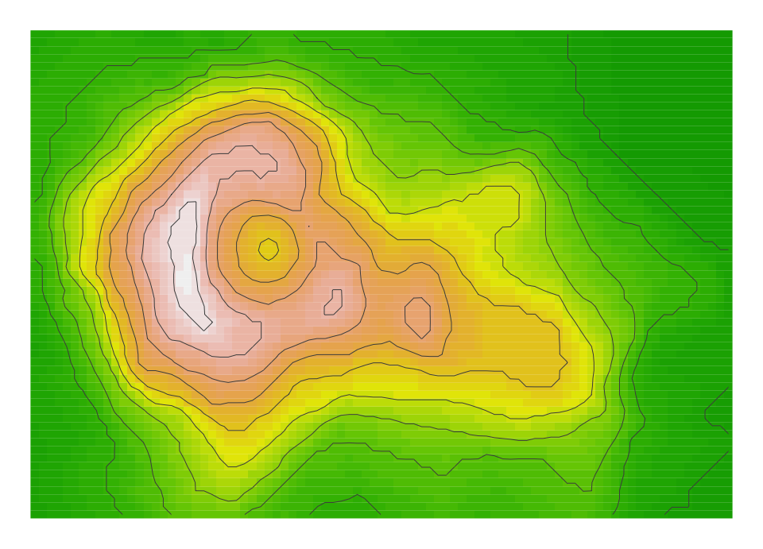

`image(volcano)` dessine la matrice comme une carte de chaleur : une **image en niveaux de gris est une matrice**.

## À vous

1. Créez la matrice 4 × 5 contenant les entiers de 1 à 20, remplie **par ligne**. Nommez les lignes `L1`…`L4` et les colonnes `C1`…`C5`.
2. Extrayez la 3<sup>e</sup> colonne sous forme de **matrice**, puis les lignes 1 et 4.
3. Remplacez par 0 les multiples de 3. Combien y en avait-il ?
4. Calculez la somme de chaque ligne et la moyenne de chaque colonne.
5. Soit `M` votre matrice. Pourquoi `M %*% M` produit-il une erreur, alors que `M %*% t(M)` fonctionne ? Quelles sont les dimensions du résultat ?

# Les arrays

## Plus de deux dimensions

Un **array** généralise la matrice à $k$ dimensions :

```r
ar <- array(1:24, dim = c(2, 3, 4))      # 2 lignes, 3 colonnes, 4 « couches »
dim(ar)
```

```
#> [1] 2 3 4
```

```r
ar[, , 1]                                # première couche : une matrice
```

```
#>      [,1] [,2] [,3]
#> [1,]    1    3    5
#> [2,]    2    4    6
```

```r
ar[2, 3, ]                               # un élément dans chaque couche
```

```
#> [1]  6 12 18 24
```

Exemples d’usage : des mesures (individu × variable × temps), une image en couleur (hauteur × largeur × canal RVB), un tableau de contingence à plusieurs entrées.

## Un array réel : `Titanic`

`Titanic` est un tableau de contingence à **4 dimensions** : classe × sexe × âge × survie.

```r
dim(Titanic)
```

```
#> [1] 4 2 2 2
```

```r
dimnames(Titanic)
```

```
#> $Class
#> [1] "1st"  "2nd"  "3rd"  "Crew"
#>
#> $Sex
#> [1] "Male"   "Female"
#>
#> $Age
#> [1] "Child" "Adult"
#>
#> $Survived
#> [1] "No"  "Yes"
```

```r
Titanic["Crew", "Male", "Adult", ]       # hommes adultes de l'équipage
```

```
#>  No Yes
#> 670 192
```

## Agréger un array

On résume un array en choisissant les dimensions à **garder** (argument `MARGIN`) :

```r
apply(Titanic, c(1, 4), sum)                        # classe × survie
```

```
#>       Survived
#> Class   No Yes
#>   1st  122 203
#>   2nd  167 118
#>   3rd  528 178
#>   Crew 673 212
```

```r
round(100 * prop.table(apply(Titanic, c(1, 4), sum), margin = 1), 1)   # % par classe
```

```
#>       Survived
#> Class    No  Yes
#>   1st  37.5 62.5
#>   2nd  58.6 41.4
#>   3rd  74.8 25.2
#>   Crew 76.0 24.0
```

La survie dépend fortement de la classe : environ 62 % en 1<sup>re</sup> classe contre 25 % en 3<sup>e</sup>. Le TP vérifie la règle « les femmes et les enfants d’abord ».

# Les listes

## Pourquoi des listes ?

Un vecteur, une matrice ou un array n’ont qu’un seul type. Une liste peut contenir n’importe quels objets, de types et de tailles différents, y compris d’autres listes.

```r
etudiant <- list(
  nom     = "Awa Diallo",
  age     = 24,
  notes   = c(R = 15, stat = 13.5, eco = 11),
  inscrit = TRUE,
  options = c("data science", "économétrie")
)
str(etudiant)
```

```
#> List of 5
#>  $ nom    : chr "Awa Diallo"
#>  $ age    : num 24
#>  $ notes  : Named num [1:3] 15 13.5 11
#>   ..- attr(*, "names")= chr [1:3] "R" "stat" "eco"
#>  $ inscrit: logi TRUE
#>  $ options: chr [1:2] "data science" "économétrie"
```

## Trois façons d’accéder à un élément

```r
etudiant$notes            # par nom → le contenu
```

```
#>    R stat  eco
#> 15.0 13.5 11.0
```

```r
etudiant[["notes"]]       # par nom ou position → le contenu
```

```
#>    R stat  eco
#> 15.0 13.5 11.0
```

```r
etudiant["notes"]         # → une LISTE d'un élément qui contient les notes
```

```
#> $notes
#>    R stat  eco
#> 15.0 13.5 11.0
```

**L’image du train**

Une liste est un train. `etudiant[2]` détache un wagon : c’est encore une liste. `etudiant[[2]]` sort le contenu du wagon.

On retrouve exactement la différence `df["age"]` / `df[["age"]]` des data frames : un data frame est une liste de colonnes.

## Accéder en profondeur, modifier

```r
etudiant$notes["stat"]               # un élément du vecteur notes
```

```
#> stat
#> 13.5
```

```r
etudiant[["options"]][2]
```

```
#> [1] "économétrie"
```

```r
etudiant$age <- 25                   # modifier
etudiant$ville <- "Paris"            # ajouter
etudiant$inscrit <- NULL             # supprimer
names(etudiant)
```

```
#> [1] "nom"     "age"     "notes"   "options" "ville"
```

```r
length(etudiant)
```

```
#> [1] 5
```

## Listes imbriquées

```r
promo <- list(
  intitule = "Introduction à R",
  annee    = 2026,
  etudiants = list(
    list(nom = "Awa",   notes = c(15, 13.5)),
    list(nom = "Bruno", notes = c(9, 12))
  )
)
```

```r
promo$etudiants[[2]]$nom                   # le nom du 2e étudiant
```

```
#> [1] "Bruno"
```

```r
promo[["etudiants"]][[1]][["notes"]][2]    # la 2e note du 1er étudiant
```

```
#> [1] 13.5
```

```r
str(promo, max.level = 1)                  # vue d'ensemble, sans tout déplier
```

```
#> List of 3
#>  $ intitule : chr "Introduction à R"
#>  $ annee    : num 2026
#>  $ etudiants:List of 2
```

## `unlist()`, `lengths()` et `strsplit()`

```r
unlist(list(a = 1, b = 2:3, c = 4))       # aplatir en un vecteur
```

```
#>  a b1 b2  c
#>  1  2  3  4
```

```r
phrases <- c("R est un langage", "les listes sont partout", "bravo")
mots <- strsplit(phrases, " ")            # une liste : un vecteur de mots par phrase
mots
```

```
#> [[1]]
#> [1] "R"       "est"     "un"      "langage"
#>
#> [[2]]
#> [1] "les"     "listes"  "sont"    "partout"
#>
#> [[3]]
#> [1] "bravo"
```

```r
lengths(mots)                             # longueur de chaque élément
```

```
#> [1] 4 4 1
```

## Les fonctions renvoient des listes

La plupart des fonctions statistiques renvoient une **liste** de résultats :

```r
test <- t.test(extra ~ group, data = sleep)      # effet de deux somnifères
class(test); typeof(test)
```

```
#> [1] "htest"
#> [1] "list"
```

```r
names(test)
```

```
#>  [1] "statistic"   "parameter"   "p.value"     "conf.int"
#>  [5] "estimate"    "null.value"  "stderr"      "alternative"
#>  [9] "method"      "data.name"
```

```r
test$p.value
```

```
#> [1] 0.07939414
```

```r
test$conf.int
```

```
#> [1] -3.3654832  0.2054832
#> attr(,"conf.level")
#> [1] 0.95
```

Savoir naviguer dans une liste, c’est savoir **récupérer un résultat** (une p-valeur, un coefficient, un intervalle de confiance) pour l’utiliser dans la suite du code ou dans le texte du rapport : `` `r round(test$p.value, 3)` ``.

## Explorer une sortie inconnue

```r
modele <- lm(mpg ~ wt, data = mtcars)   # consommation selon le poids
names(modele)                           # ce que contient la liste
```

```
#>  [1] "coefficients"  "residuals"     "effects"       "rank"
#>  [5] "fitted.values" "assign"        "qr"            "df.residual"
#>  [9] "xlevels"       "call"          "terms"         "model"
```

```r
modele$coefficients
```

```
#> (Intercept)          wt
#>   37.285126   -5.344472
```

```r
summary(modele)$r.squared
```

```
#> [1] 0.7528328
```

Le réflexe : `names()` et `str(x, max.level = 1)`. L’onglet *Environment* de RStudio permet aussi de déplier une liste.

## À vous

1. Créez une liste `cours` contenant : l’intitulé `"Introduction à R"`, le nombre de séances `9`, un vecteur nommé des horaires (`debut = "18:00"`, `fin = "21:30"`) et un data frame de 3 étudiants (nom, âge).
2. Affichez l’heure de fin de trois façons différentes.
3. Quelle est la classe de `cours[3]` ? Et celle de `cours[[3]]` ?
4. Ajoutez un élément `salle`, puis supprimez le nombre de séances.
5. Avec `test <- t.test(extra ~ group, data = sleep)`, rédigez une phrase qui donne la p-valeur arrondie à 3 décimales **avec du code R dans le texte**.

# Bilan des structures

## Quelle structure pour quel usage ?

| Structure | Dimensions | Types | Créer | Accéder |
| --- | --- | --- | --- | --- |
| vecteur | 1 | un seul | `c()`, `seq()` | `x[i]` |
| facteur | 1 | qualitatif (niveaux) | `factor()` | `f[i]` |
| matrice | 2 | un seul | `matrix()` | `m[i, j]` |
| array | *k* | un seul | `array()` | `a[i, j, k]` |
| liste | 1 (éléments variés) | **quelconques** | `list()` | `l[[i]]`, `l$nom` |
| data frame | 2 | un par **colonne** | `data.frame()` | `df[i, j]`, `df$col` |

- **Données tabulaires** (individus × variables de types variés) : un data frame.
- **Calcul numérique homogène** (algèbre, images, distances) : une matrice ou un array.
- **Objets hétérogènes** (résultats, paramètres, configurations) : une liste.

## Conversions

```r
df <- data.frame(x = 1:3, y = c("a", "b", "c"))
as.matrix(df)                # attention : un seul type possible : tout devient du texte
```

```
#>      x   y
#> [1,] "1" "a"
#> [2,] "2" "b"
#> [3,] "3" "c"
```

```r
m <- matrix(1:4, 2)
as.data.frame(m)             # noms de colonnes V1, V2
```

```
#>   V1 V2
#> 1  1  3
#> 2  2  4
```

```r
as.vector(m)                 # lecture colonne par colonne
```

```
#> [1] 1 2 3 4
```

`as.list(df)` transforme un data frame en liste de colonnes ; `unlist()` aplatit une liste en vecteur.

## Les pièges à connaître

| Piège | Exemple | Correction |
| --- | --- | --- |
| `*` au lieu de `%*%` | `A * B` fait un produit case par case | `A %*% B` |
| Dimensions incompatibles | `A %*% B` avec `ncol(A) != nrow(B)` | vérifier `dim()` |
| Perte de dimension | `m[, 1]` devient un vecteur | `drop = FALSE` |
| `as.matrix()` d’un data frame mixte | tout devient du texte | ne garder que les colonnes numériques |
| `[ ]` au lieu de `[[ ]]` sur une liste | on obtient une liste, pas le contenu | `[[ ]]` ou `$` |
| Remplissage par colonne | `matrix(1:6, 2)` ne donne pas `1 2 3` sur la 1<sup>re</sup> ligne | `byrow = TRUE` |

# Synthèse

## Récapitulatif

**Matrices et arrays**

- un vecteur + des dimensions, **un seul type**
- `matrix(x, nrow, ncol, byrow)`, `rbind`, `cbind`
- `m[i, j]`, noms, `drop = FALSE`
- `which(..., arr.ind = TRUE)`
- `*` case par case, `%*%` matriciel
- `rowSums`, `apply`

**Listes**

- des éléments de **types quelconques**
- `l[[i]]`, `l$nom` : le contenu
- `l[i]` : une sous-liste
- `str(l, max.level = 1)` pour explorer
- `unlist()`, `lengths()`
- résultats de `t.test()`, `lm()`… = des listes
- un data frame est une liste de colonnes

**Prochaine séance :** importer, exporter et ranger ses données (CSV, Excel, *tidy data*).

## TP de la séance 4

L’énoncé est en PDF sur Moodle : `S04_TP_enonce.pdf`. Vous rédigez votre propre document `tp4_nom_prenom.Rmd` dans le dossier du TP (`tp4.zip` sur Moodle, à décompresser).

- **Partie A :** construire et manipuler des matrices
- **Partie B :** algèbre linéaire appliquée
- **Partie C :** le Titanic, un array à 4 dimensions
- **Partie D :** listes et résultats de fonctions
- Chunk `setup` : `source("donnees_tp4.R")`.
- Structure : `# Partie A`, puis `## A1`, `## A2`… comme dans l’énoncé, avec une phrase de réponse par question.
- **Rendu :** le `.Rmd` et le `.html` knitté sans erreur, à déposer sur Moodle. Date limite : voir Moodle.